# Prediction project

Thomas Bruno Michelon

2022-05-03

# Prediction project assigment

Loading packages from a loop:

```r
packages <- as.data.frame(c("esquisse", "tidyverse", "dplyr", "AppliedPredictiveModeling", "caret", "pgmm", "rpart", "gbm", "lubridate", "forecast", "e1071"))
for (i in 1:dim(packages)[1]) {
  try(library(packages[i, 1], character.only = T))
}
```

Loading data:

```r
training <- read.csv(url("https://d396qusza40orc.cloudfront.net/predmachlearn/pml-training.csv"), na.strings = c("NA", "#DIV/0!", ""))
testing <- read.csv(url("https://d396qusza40orc.cloudfront.net/predmachlearn/pml-testing.csv"), na.strings = c("NA", "#DIV/0!", ""))
```

Set variable “classe” as factor

```r
training <- mutate(training, classe = as.factor(classe))
```

## Data-split

The testing data comes without label, so in order to evaluate the prediction models, the training set will be split in calibration and prediction set:

```r
set.seed(3455)
inTrain <- createDataPartition(training$classe, p = 0.7, list = FALSE)
split_training <- training[inTrain, ]
split_testing <- training[-inTrain, ]
dim(split_training)
```

```
## [1] 13737   160
```

```r
dim(split_testing)
```

```
## [1] 5885  160
```

## Data cleaning

Since the data frame came with high empty columns and variables not interesting for prediction (e.g., user name), we must provide a clean data set before begin the analysis. In this section it will be also used as data inspection.

###Data cleaning - Removing NA columns

```r
# Finding columns with more than 50% NA
NA_cols_index <- which(colMeans(is.na(split_training)) > 0.5)
# Remove columns
split_training <- split_training[, -NA_cols_index]
# Check Dimensions
dim(split_training)
```

```
## [1] 13737    60
```

###Data cleaning - Removing not necessary columns

```r
# Removing X, user name, new window, num window and, timestamp columns
split_training <- subset(split_training, select = -c(X, user_name, new_window, num_window, cvtd_timestamp))
dim(split_training)
```

```
## [1] 13737    55
```

###Data cleaning - Checking for Near Zero Variances

```r
nearZeroVar(split_training, saveMetrics = T)
```

```
##                      freqRatio percentUnique zeroVar   nzv
## raw_timestamp_part_1  1.000000    6.09303341   FALSE FALSE
## raw_timestamp_part_2  1.250000   89.37904928   FALSE FALSE
## roll_belt             1.126198    8.00029118   FALSE FALSE
## pitch_belt            1.035461   12.26614253   FALSE FALSE
## yaw_belt              1.041899   13.00138313   FALSE FALSE
## total_accel_belt      1.066153    0.19654946   FALSE FALSE
## gyros_belt_x          1.040373    0.93906967   FALSE FALSE
## gyros_belt_y          1.120192    0.47317464   FALSE FALSE
## gyros_belt_z          1.078037    1.16473757   FALSE FALSE
## accel_belt_x          1.075646    1.13561913   FALSE FALSE
## accel_belt_y          1.114312    1.00458615   FALSE FALSE
## accel_belt_z          1.101974    2.12564607   FALSE FALSE
## magnet_belt_x         1.101961    2.19844216   FALSE FALSE
## magnet_belt_y         1.073991    2.04557036   FALSE FALSE
## magnet_belt_z         1.005952    3.18118949   FALSE FALSE
## roll_arm             50.957447   17.53658004   FALSE FALSE
## pitch_arm            82.620690   20.34650943   FALSE FALSE
## yaw_arm              33.732394   19.15265342   FALSE FALSE
## total_accel_arm       1.012461    0.46589503   FALSE FALSE
## gyros_arm_x           1.067416    4.58615418   FALSE FALSE
## gyros_arm_y           1.480556    2.66433719   FALSE FALSE
## gyros_arm_z           1.097113    1.67431026   FALSE FALSE
## accel_arm_x           1.051282    5.59801995   FALSE FALSE
## accel_arm_y           1.219178    3.80723593   FALSE FALSE
## accel_arm_z           1.086022    5.53250346   FALSE FALSE
## magnet_arm_x          1.000000    9.56540729   FALSE FALSE
## magnet_arm_y          1.016393    6.17310912   FALSE FALSE
## magnet_arm_z          1.000000    9.10679188   FALSE FALSE
## roll_dumbbell         1.083333   87.21700517   FALSE FALSE
## pitch_dumbbell        2.296703   84.82201354   FALSE FALSE
## yaw_dumbbell          1.096386   86.51088302   FALSE FALSE
## total_accel_dumbbell  1.048504    0.31302322   FALSE FALSE
## gyros_dumbbell_x      1.002252    1.69614909   FALSE FALSE
## gyros_dumbbell_y      1.205011    1.97277426   FALSE FALSE
## gyros_dumbbell_z      1.037471    1.41952391   FALSE FALSE
## accel_dumbbell_x      1.043668    2.99191963   FALSE FALSE
## accel_dumbbell_y      1.095238    3.29766325   FALSE FALSE
## accel_dumbbell_z      1.216049    2.93368275   FALSE FALSE
## magnet_dumbbell_x     1.066116    7.75278445   FALSE FALSE
## magnet_dumbbell_y     1.245614    5.99839849   FALSE FALSE
## magnet_dumbbell_z     1.104478    4.81182209   FALSE FALSE
## roll_forearm         11.069388   13.58375191   FALSE FALSE
## pitch_forearm        64.571429   19.00706122   FALSE FALSE
## yaw_forearm          15.403409   12.85579093   FALSE FALSE
## total_accel_forearm   1.118857    0.48045425   FALSE FALSE
## gyros_forearm_x       1.028721    2.05284997   FALSE FALSE
## gyros_forearm_y       1.035714    5.22675985   FALSE FALSE
## gyros_forearm_z       1.049861    2.09652763   FALSE FALSE
## accel_forearm_x       1.174603    5.67809565   FALSE FALSE
## accel_forearm_y       1.157143    7.13401762   FALSE FALSE
## accel_forearm_z       1.084112    4.01834462   FALSE FALSE
## magnet_forearm_x      1.178571   10.51175657   FALSE FALSE
## magnet_forearm_y      1.200000   13.27800830   FALSE FALSE
## magnet_forearm_z      1.022727   11.69105336   FALSE FALSE
## classe                1.469526    0.03639805   FALSE FALSE
```

None NZV found

## Pre-processing

After the data cleaning, we should search for high correlated predictors, since high correlation between predictors means high variance and it is bad for the prediction model.

```r
# Correlation matrix without y variable (classe)
cor_matrix <- cor(subset(split_training, select = -classe))
# Modify correlation matrix - upper triangular part of the matrix equal 0
cor_matrix[upper.tri(cor_matrix)] <- 0
# Modify correlation matrix - diagonal part of the matrix equal 0
diag(cor_matrix) <- 0
head(cor_matrix)
```

```
##                      raw_timestamp_part_1 raw_timestamp_part_2  roll_belt
## raw_timestamp_part_1          0.000000000         0.0000000000  0.0000000
## raw_timestamp_part_2         -0.009398254         0.0000000000  0.0000000
## roll_belt                     0.373722616         0.0048064645  0.0000000
## pitch_belt                    0.193449154         0.0054739201 -0.2134403
## yaw_belt                      0.167547982         0.0005114406  0.8166650
## total_accel_belt              0.374221456         0.0047668393  0.9814025
##                      pitch_belt  yaw_belt total_accel_belt gyros_belt_x
## raw_timestamp_part_1  0.0000000 0.0000000                0            0
## raw_timestamp_part_2  0.0000000 0.0000000                0            0
## roll_belt             0.0000000 0.0000000                0            0
## pitch_belt            0.0000000 0.0000000                0            0
## yaw_belt             -0.7018233 0.0000000                0            0
## total_accel_belt     -0.1376147 0.7638381                0            0
##                      gyros_belt_y gyros_belt_z accel_belt_x accel_belt_y
## raw_timestamp_part_1            0            0            0            0
## raw_timestamp_part_2            0            0            0            0
## roll_belt                       0            0            0            0
## pitch_belt                      0            0            0            0
## yaw_belt                        0            0            0            0
## total_accel_belt                0            0            0            0
##                      accel_belt_z magnet_belt_x magnet_belt_y magnet_belt_z
## raw_timestamp_part_1            0             0             0             0
## raw_timestamp_part_2            0             0             0             0
## roll_belt                       0             0             0             0
## pitch_belt                      0             0             0             0
## yaw_belt                        0             0             0             0
## total_accel_belt                0             0             0             0
##                      roll_arm pitch_arm yaw_arm total_accel_arm gyros_arm_x
## raw_timestamp_part_1        0         0       0               0           0
## raw_timestamp_part_2        0         0       0               0           0
## roll_belt                   0         0       0               0           0
## pitch_belt                  0         0       0               0           0
## yaw_belt                    0         0       0               0           0
## total_accel_belt            0         0       0               0           0
##                      gyros_arm_y gyros_arm_z accel_arm_x accel_arm_y
## raw_timestamp_part_1           0           0           0           0
## raw_timestamp_part_2           0           0           0           0
## roll_belt                      0           0           0           0
## pitch_belt                     0           0           0           0
```

[output cut: 57 more lines]

```
## total_accel_belt                   0               0               0
##                      accel_forearm_z magnet_forearm_x magnet_forearm_y
## raw_timestamp_part_1               0                0                0
## raw_timestamp_part_2               0                0                0
## roll_belt                          0                0                0
## pitch_belt                         0                0                0
## yaw_belt                           0                0                0
## total_accel_belt                   0                0                0
##                      magnet_forearm_z
## raw_timestamp_part_1                0
## raw_timestamp_part_2                0
## roll_belt                           0
## pitch_belt                          0
## yaw_belt                            0
## total_accel_belt                    0
```

```r
# removing high correlated variables
split_training_correlation <- split_training[, !apply(
  cor_matrix,
  2,
  function(x) any(abs(x) > 0.9)
)]
# Checking dimensions
dim(split_training_correlation)
```

```
## [1] 13737    48
```

```r
# Set back to original data frame
split_training <- split_training_correlation
```

## Prediction model

### Model 1 - Classification tree

```r
modCT <- rpart(classe ~ ., data = split_training)
```

Model 1 - training accuracy

```r
# predict training
predCT_training <- predict(modCT, type = "class")
# Confusion matrix training
tableCT_training <- table(predCT_training, split_training$classe)
# Accuracy training
sum(diag(tableCT_training)) / sum(tableCT_training)
```

```
## [1] 0.7789182
```

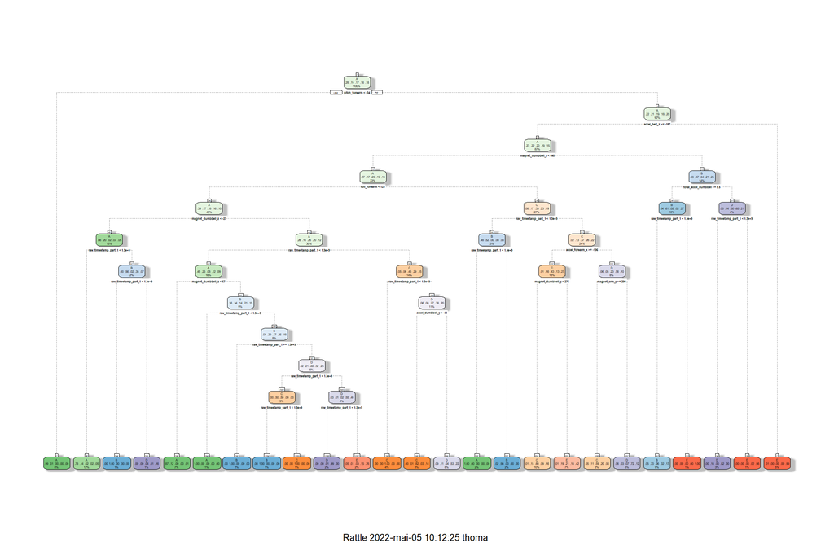

```r
rattle::fancyRpartPlot(modCT)
```

Model 1 - testing accuracy

```r
# predict testing
predCT_testing <- predict(modCT, split_testing, type = "class")
# Confusion matrix testing
tableCT_testing <- table(predCT_testing, split_testing$classe)
# testing accuracy
sum(diag(tableCT_testing)) / sum(tableCT_testing)
```

```
## [1] 0.7758709
```

The first model did not provide a good accuracy, we should test another algorithm.

### Model 2 - Random forest model

```r
modRF <- randomForest::randomForest(classe ~ ., data = split_training)
```

Model 2 - training accuracy

```r
# Predict training
pred_training <- predict(modRF, split_training)
# Confusion matrix training
confusionMatrix(pred_training, split_training$classe)
```

```
## Confusion Matrix and Statistics
##
##           Reference
## Prediction    A    B    C    D    E
##          A 3906    0    0    0    0
##          B    0 2658    0    0    0
##          C    0    0 2396    0    0
##          D    0    0    0 2252    0
##          E    0    0    0    0 2525
##
## Overall Statistics
##
##                Accuracy : 1
##                  95% CI : (0.9997, 1)
##     No Information Rate : 0.2843
##     P-Value [Acc > NIR] : < 2.2e-16
##
##                   Kappa : 1
##
##  Mcnemar's Test P-Value : NA
##
## Statistics by Class:
##
##                      Class: A Class: B Class: C Class: D Class: E
## Sensitivity            1.0000   1.0000   1.0000   1.0000   1.0000
## Specificity            1.0000   1.0000   1.0000   1.0000   1.0000
## Pos Pred Value         1.0000   1.0000   1.0000   1.0000   1.0000
## Neg Pred Value         1.0000   1.0000   1.0000   1.0000   1.0000
## Prevalence             0.2843   0.1935   0.1744   0.1639   0.1838
## Detection Rate         0.2843   0.1935   0.1744   0.1639   0.1838
## Detection Prevalence   0.2843   0.1935   0.1744   0.1639   0.1838
## Balanced Accuracy      1.0000   1.0000   1.0000   1.0000   1.0000
```

Model 2 - Testing accuracy

```r
# Predict testing
pred_testing <- predict(modRF, split_testing)
confusionMatrix(pred_testing, split_testing$classe)
```

```
## Confusion Matrix and Statistics
##
##           Reference
## Prediction    A    B    C    D    E
##          A 1673    2    0    0    0
##          B    1 1137    5    0    0
##          C    0    0 1021    6    0
##          D    0    0    0  958    7
##          E    0    0    0    0 1075
##
## Overall Statistics
##
##                Accuracy : 0.9964
##                  95% CI : (0.9946, 0.9978)
##     No Information Rate : 0.2845
##     P-Value [Acc > NIR] : < 2.2e-16
##
##                   Kappa : 0.9955
##
##  Mcnemar's Test P-Value : NA
##
## Statistics by Class:
##
##                      Class: A Class: B Class: C Class: D Class: E
## Sensitivity            0.9994   0.9982   0.9951   0.9938   0.9935
## Specificity            0.9995   0.9987   0.9988   0.9986   1.0000
## Pos Pred Value         0.9988   0.9948   0.9942   0.9927   1.0000
## Neg Pred Value         0.9998   0.9996   0.9990   0.9988   0.9985
## Prevalence             0.2845   0.1935   0.1743   0.1638   0.1839
## Detection Rate         0.2843   0.1932   0.1735   0.1628   0.1827
## Detection Prevalence   0.2846   0.1942   0.1745   0.1640   0.1827
## Balanced Accuracy      0.9995   0.9985   0.9969   0.9962   0.9968
```

The final model using random forest algorithm provided high accuracy > 99%. So, it can be used as a prediction model for the testing data frame provided.

Model 2 - Predict on original testing data frame (provide for project)

```r
pred_validation <- predict(modRF, testing)
pred_validation
```

```
##  1  2  3  4  5  6  7  8  9 10 11 12 13 14 15 16 17 18 19 20
##  B  A  B  A  A  E  D  B  A  A  B  C  B  A  E  E  A  B  B  B
## Levels: A B C D E
```